# 02_clean

Author

Group_23

# 05. Analysis - PCA

```r
library(tidyverse)
library(broom)
library(cowplot)
```

In this section, we use Principal Components Analysis (PCA) as a way to inspect the data and try to unveil underlying patterns. We color code according to different variables to whether a possible clustering observed in the two first principal components aligns with a particular variable.

In particular, we conduct 4 different analysis:

1. Considering all proteomic data for all individuals, but excluding clinical data.
2. Considering the proteomic data for the PAM50 proteins for all individuals, but excluding clinical data.
3. Considering all the protemic data and the clinical data for the individuals with cancer (we exclude the healthy because they lack clinical data).
4. Considering the proteomic data for the PAM50 proteins and the clinical data only for the individuals with cancer (as the healthy ones lack clinical data).

## 05.1. Load data from .tsv files

```r
prot_clin <- read.delim("../data/03_dat_aug.tsv")
```

## 05.2. PCA for all individuals based on all proteomic data.

In our initial analysis, we examine the proteomic data across all samples, taking into account both cancerous and healthy individuals. Our aim is to analyze if differences in the proteomes allow to see differences individuals.

Hence, in this first analysis we do not use the clinical data. First, we get a subset only with the proteomic data. All of the values are numeric, so the `prcomp()` function can work with them without further processing.

```r
proteomes <- prot_clin |>
  select(#Complete.TCGA.ID,
         matches("^NP"),
         matches("^XP"),
         matches("^YP"))
```

In this case, it is not necessary to scale the data.

```r
pca_prot_fit <- proteomes |>
  prcomp(scale=FALSE)
```

First, we plot the data on the two first principal components.

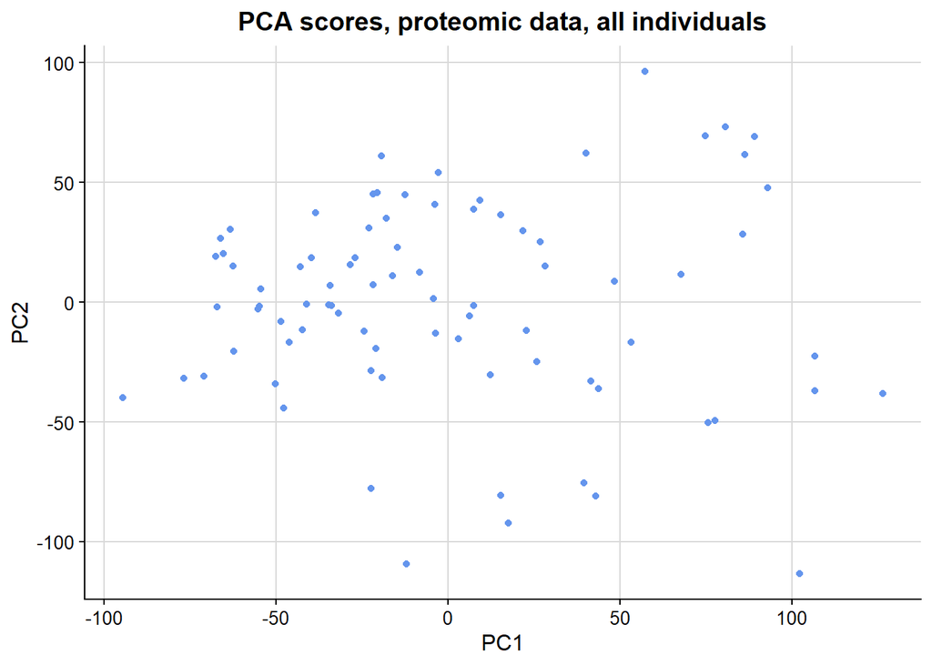

```r
pca_scores <- as.data.frame(predict(pca_prot_fit))

ggplot(pca_scores, aes(PC1, PC2)) +
  geom_point(size = 1.5, color = "cornflowerblue") +
  labs(title = "PCA scores, proteomic data, all individuals",
       x = "PC1",
       y = "PC2") +
  theme_half_open(12) +
  background_grid() +
  theme(plot.title = element_text(hjust = 0.5))
```

Before proceeding with any further analysis, we can inspect the amount of variance explained by the first principal components.

```r
pca_prot_fit |>
  tidy(matrix = "eigenvalues")
```

```
# A tibble: 83 × 4
      PC std.dev percent cumulative
   <dbl>   <dbl>   <dbl>      <dbl>
 1     1    51.6  0.132       0.132
 2     2    42.1  0.0878      0.220
 3     3    40.3  0.0805      0.300
 4     4    28.9  0.0412      0.342
 5     5    28.3  0.0395      0.381
 6     6    27.0  0.0362      0.417
 7     7    22.9  0.0260      0.443
 8     8    21.5  0.0229      0.466
 9     9    20.1  0.0200      0.486
10    10    19.9  0.0195      0.506
# ℹ 73 more rows
```

When calculating the variance explained, we can see that the two first principal components only account for 22% of the total variation. This may be one of the reasons why, in the further analysis we don’t see a clear clustering of the samples when plotting the PCA results on PC1 and PC2. In fact, the first 10 principal components are necessary to reach 50% of the variation.

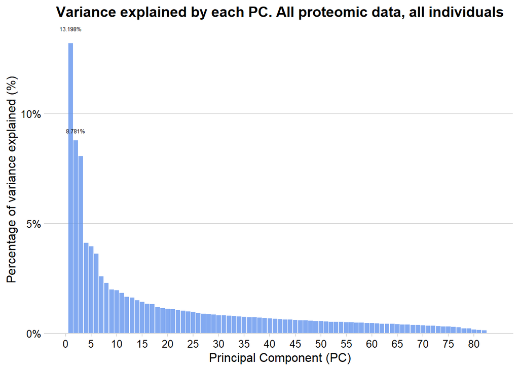

```r
pca_prot_fit |>
  tidy(matrix = "eigenvalues") |>
  ggplot(aes(PC,
             percent)) +
  geom_col(fill = "cornflowerblue",
           alpha = 0.8) +
  scale_x_continuous(breaks = seq(0,
                                  80,
                                  by = 5)) +
  scale_y_continuous(labels = scales::percent_format(),
                     expand = expansion(mult = c(0,
                                                 0.01))) +
  geom_text(mapping = aes(label = ifelse(PC %in% c(1, 2),
                                         scales::percent(percent),
                                         "")),
            position = position_stack(vjust = 1.05),
            color = "black",
            size = 2) +
  theme_minimal_hgrid(12) +
  labs(title = "Variance explained by each PC. All proteomic data, all individuals",
       x = "Principal Component (PC)",
       y = "Percentage of variance explained (%)") +
  theme(plot.title = element_text(hjust = 0.5))
```

Since we want to analyze possible differences between cancer patients and healthy individuals, we create new variables for differentiating them. For a deeper analysis, in one variable, we will group the individuals with cancer according to the type of tumor they have, and in the other variable according to the AJCC stage.

```r
prot_clin_exp <- prot_clin |>
  mutate(
    Cancer_tumor = case_when(
      row_number() > n() - 3 ~ "Healthy",
      Tumor == "T1" ~ "T1",
      Tumor == "T2" ~ "T2",
      Tumor == "T3" ~ "T3",
      Tumor == "T4" ~ "T4"
    )
  ) |>
  relocate(Cancer_tumor, .after = Tumor)
```

```r
prot_clin_exp <- prot_clin_exp |>
  mutate(
    Cancer_AJCC = case_when(
      row_number() > n() - 3 ~ "Healthy",
      AJCC.Simp == "Stage I" ~ "Stage I",
      AJCC.Simp == "Stage II" ~ "Stage II",
      AJCC.Simp == "Stage III" ~ "Stage III",
      AJCC.Simp == "Stage IV" ~ "Stage IV"
    )
  ) |>
  relocate(Cancer_AJCC, .after = AJCC.Simp)
```

We can plot the data on the first two principal components, and color according to tumor. However, it is not possible to appreciate any clustering by type of tumor.

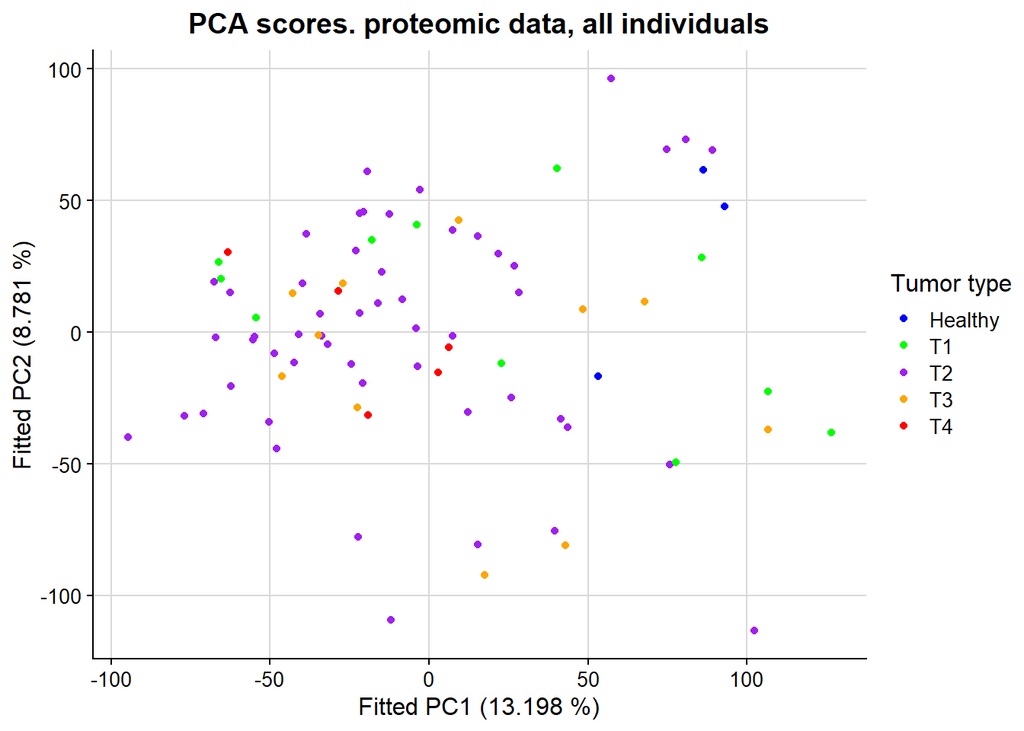

```r
pca_prot_fit |>
  augment(prot_clin_exp) |>
  ggplot(aes(.fittedPC1, .fittedPC2, color = Cancer_tumor)) +
  geom_point(size = 1.5) +
  scale_color_manual(
    values = c(T1 = "green",
               T2 = "purple",
               T3 = "orange",
               T4 = "red",
               Healthy = "blue")) +
  labs(title = "PCA scores. proteomic data, all individuals",
       x = "Fitted PC1 (13.198 %)",
       y = "Fitted PC2 (8.781 %)",
       color = "Tumor type") +
  theme_half_open(12) +
  background_grid() +
  theme(plot.title = element_text(hjust = 0.5))
```

We can also color according to the AJCC stage, but the results are not better.

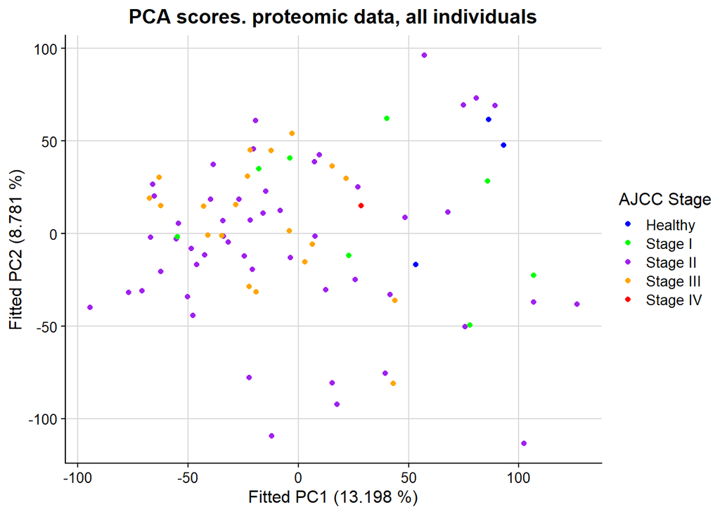

```r
pca_prot_fit |>
  augment(prot_clin_exp) |>
  ggplot(aes(.fittedPC1, .fittedPC2, color = Cancer_AJCC)) +
  geom_point(size = 1.5) +
  scale_color_manual(
    values = c("Stage I" = "green",
               "Stage II" = "purple",
               "Stage III" = "orange",
               "Stage IV" = "red",
               Healthy = "blue")) +
  labs(title = "PCA scores. proteomic data, all individuals",
       x = "Fitted PC1 (13.198 %)",
       y = "Fitted PC2 (8.781 %)",
       color = "AJCC Stage") +
  theme_half_open(12) +
  background_grid() +
  theme(plot.title = element_text(hjust = 0.5))
```

Thus, at first sight (when plotting on the two first principal components). it is not possible to establish any type of clustering regarding tumor type or AJCC stages when considering all proteomic data for all individuals. However, this results are not conclusive, as the two first principal components only account for 22% of the variation of the data.

## 05.3. PCA for all individuals based on PAM50 proteomic data.

We decided to do an analysis for a subset of selected proteins: those indicated in the PAM50 data set, known to be related to breast cancer.

```r
# Read PAM50 metadata file
PAM50_ref <- read.delim("../data/_raw/PAM50_proteins.csv",
                        sep = ",") |>
  select(RefSeqProteinID)

PAM50_ref_names <- PAM50_ref |>
  pull(RefSeqProteinID)

# Select only the protein-expression data for the PAM50 genes
PAM50_data <- prot_clin |>
  select(one_of(PAM50_ref_names))
```

We perform PCA using the data from these selected proteins.

```r
pca_PAM50_fit <- PAM50_data |>
  prcomp(scale=FALSE)
```

When can plot the data on the two first principal components.

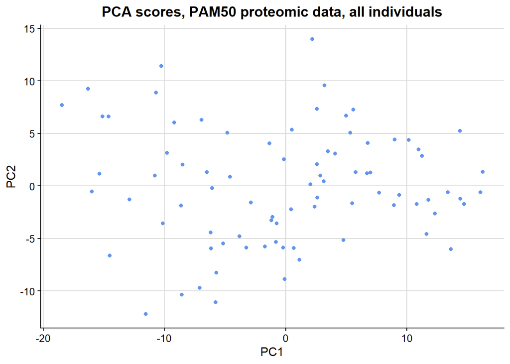

```r
pca_scores <- as.data.frame(predict(pca_PAM50_fit))

ggplot(pca_scores, aes(PC1, PC2)) +
  geom_point(size = 1.5, color = "cornflowerblue") +
  labs(title = "PCA scores, PAM50 proteomic data, all individuals",
       x = "PC1",
       y = "PC2") +
  theme_half_open(12) +
  background_grid() +
  theme(plot.title = element_text(hjust = 0.5))
```

In this case, the variance explained is much higher. By selecting proteins that are known to be related to cancer, the amount of variance explained by the first principal components increases considerably. Limiting the columns to data from the PAM50 proteins, PC1 accounts for 39.54% of the variance (compared to 13.2% when using all proteins), and the two first principal components explain more than 50% of the total variance (54,1 %). Moreover, the 10 first principal components account for 88.7% of the variance.

```r
pca_PAM50_fit |>
  tidy(matrix = "eigenvalues")
```

```
# A tibble: 33 × 4
      PC std.dev percent cumulative
   <dbl>   <dbl>   <dbl>      <dbl>
 1     1    8.86  0.395       0.395
 2     2    5.38  0.145       0.541
 3     3    4.14  0.0861      0.627
 4     4    3.62  0.0660      0.693
 5     5    3.34  0.0562      0.749
 6     6    2.86  0.0410      0.790
 7     7    2.41  0.0291      0.819
 8     8    2.33  0.0274      0.847
 9     9    2.08  0.0217      0.868
10    10    1.91  0.0183      0.887
# ℹ 23 more rows
```

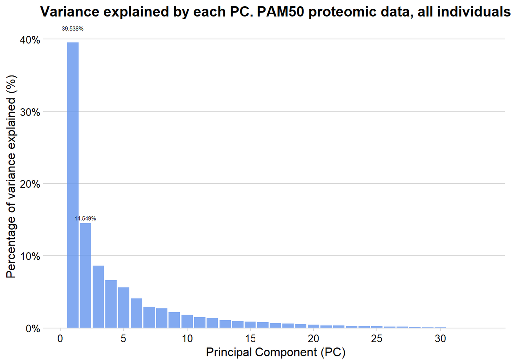

```r
pca_PAM50_fit |>
  tidy(matrix = "eigenvalues") |>
  ggplot(aes(PC,
             percent)) +
  geom_col(fill = "cornflowerblue",
           alpha = 0.8) +
  scale_x_continuous(breaks = seq(0,
                                  30,
                                  by = 5)) +
  scale_y_continuous(labels = scales::percent_format(),
                     expand = expansion(mult = c(0,
                                                 0.01))) +
  geom_text(mapping = aes(label = ifelse(PC %in% c(1, 2),
                                         scales::percent(percent),
                                         "")),
            position = position_stack(vjust = 1.05),
            color = "black",
            size = 2) +
  theme_minimal_hgrid(12) +
  labs(title = "Variance explained by each PC. PAM50 proteomic data, all individuals",
       x = "Principal Component (PC)",
       y = "Percentage of variance explained (%)") +
  theme(plot.title = element_text(hjust = 0.5))
```

Since the variance explained is much higher in this case, it can be interesting to examine more variables. We can color by type of tumor, AJCC stage, and also subtype of cancer (Basal-like, Luminal A, Luminal B, or HER2- enriched) and TNBC. First, we create new variables to allow for color coding.

```r
prot_clin_exp <- prot_clin_exp |>
  mutate(
    Cancer_subtype = case_when(
      row_number() > n() - 3 ~ "Healthy",
      PAM50.mRNA == "Basal-like" ~ "Basal-like",
      PAM50.mRNA == "Luminal A" ~ "Luminal A",
      PAM50.mRNA == "Luminal B" ~ "Luminal B",
      PAM50.mRNA == "HER2-enriched" ~ "HER2-enriched"
    )
  ) |>
  relocate(Cancer_subtype, .after = PAM50.mRNA)
```

```r
prot_clin_exp <- prot_clin_exp |>
  mutate(
    TNBC_status = case_when(
      row_number() > n() - 3 ~ "Healthy",
      TNBC == "0" ~ "Negative",
      TNBC == "1" ~ "Positive",
    )
  ) |>
  relocate(TNBC_status, .after = TNBC)
```

Now, we can plot the results.

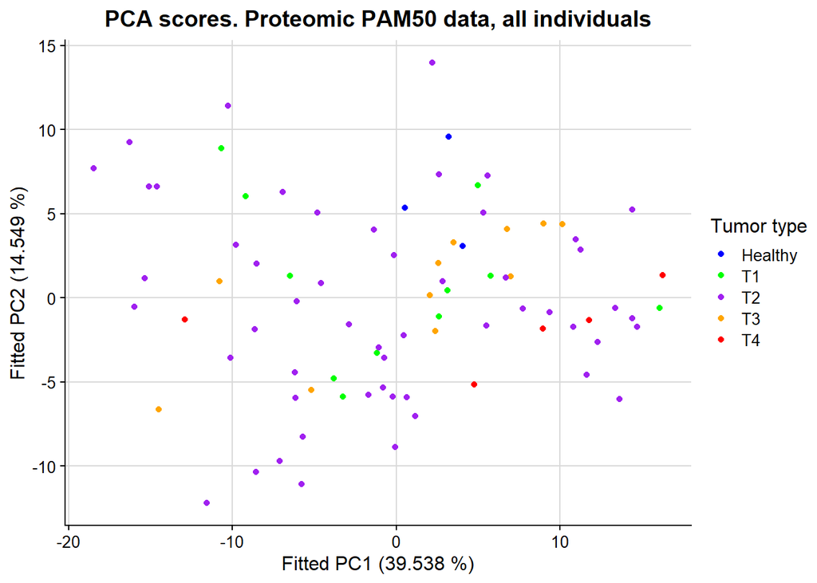

```r
pca_PAM50_fit |>
  augment(prot_clin_exp) |>
  ggplot(aes(.fittedPC1, .fittedPC2, color = Cancer_tumor)) +
  geom_point(size = 1.5) +
  scale_color_manual(
    values = c(T1 = "green",
               T2 = "purple",
               T3 = "orange",
               T4 = "red",
               Healthy = "blue")) +
  labs(title = "PCA scores. Proteomic PAM50 data, all individuals",
       x = "Fitted PC1 (39.538 %)",
       y = "Fitted PC2 (14.549 %)",
       color = "Tumor type") +
  theme_half_open(12) +
  background_grid() +
  theme(plot.title = element_text(hjust = 0.5))
```

[figure not shown]

```r
pca_PAM50_fit |>
  augment(prot_clin_exp) |>
  ggplot(aes(.fittedPC1, .fittedPC2, color = Cancer_AJCC)) +
  geom_point(size = 1.5) +
  scale_color_manual(
    values = c("Stage I" = "green",
               "Stage II" = "purple",
               "Stage III" = "orange",
               "Stage IV" = "red",
               Healthy = "blue")) +
  labs(title = "PCA scores. proteomic PAM50 data, all individuals",
       x = "Fitted PC1 (33.238 %)",
       y = "Fitted PC2 (14.549 %)",
       color = "AJCC Stage") +
  theme_half_open(12) +
  background_grid() +
  theme(plot.title = element_text(hjust = 0.5))
```

[figure not shown]

```r
pca_PAM50_fit |>
  augment(prot_clin_exp) |>
  ggplot(aes(.fittedPC1, .fittedPC2, color = Cancer_subtype)) +
  geom_point(size = 1.5) +
  scale_color_manual(
    values = c("Basal-like" = "red",
               "Luminal A" = "green",
               "Luminal B" = "orange",
               "HER2-enriched" = "purple",
               Healthy = "blue")) +
  labs(title = "PCA scores. proteomic PAM50 data, all individuals",
       x = "Fitted PC1 (39.238 %)",
       y = "Fitted PC2 (14.549 %)",
       color = "Cancer subtype") +
  theme_half_open(12) +
  background_grid() +
  theme(plot.title = element_text(hjust = 0.5))
```

[figure not shown]

```r
pca_PAM50_fit |>
  augment(prot_clin_exp) |>
  ggplot(aes(.fittedPC1, .fittedPC2, color = TNBC_status)) +
  geom_point(size = 1.5) +
  scale_color_manual(
    values = c("Negative" = "purple",
               "Positive" = "red",
               Healthy = "blue")) +
  labs(title = "PCA scores. proteomic PAM50 data, all individuals",
       x = "Fitted PC1 (33.238 %)",
       y = "Fitted PC2 (14.549 %)",
       color = "TNBC") +
  theme_half_open(12) +
  background_grid() +
  theme(plot.title = element_text(hjust = 0.5))
```

When using only the PAM50 proteins, the results are much better. The amount of variance explained is much higher, and that allows us to visualize possible clusters regarding cancer type and presence or absence of TNBC.

## 05.4. PCA for cancer samples including clinical data and all proteomic data.

In a different approach, we decided to include the clinical data to perform PCA. Since the three healthy individuals lack clinical data, and imputing values such as “No tumor” would introduce misleading correlations in the data, we decided to drop these samples in this part of the analysis, and work only with the individuals suffering from cancer.

```r
prot_clin_cancer <- prot_clin |>
  slice_head(n = -3)
```

In the next step for preparing the data, we will keep the column that classifies age according to menopause, and drop the rest of the age-related columns, since we do not want to input this information into the PCA. We also drop the samples’ IDs

```r
prot_clin_cancer <- prot_clin_cancer |>
  select(-Age.at.Initial.Pathologic.Diagnosis,
         -Age.Ini.Diagnostic.group,
         -Complete.TCGA.ID)
```

PCA can only take in numerical values. Therefore, it is necessary to label-encode the data before taking any further steps.

```r
columns_to_encode <- c("Gender",
                       "ER",
                       "PR",
                       "HER2",
                       "ER_PR_HER2",
                       "TNBC",
                       "Tumor",
                       "Node",
                       "Metastasis",
                       "AJCC.Simp",
                       "PAM50.mRNA",
                       "Age.Menopausal.group"
                       )

prot_clin_cancer_encoded <- prot_clin_cancer |>
  mutate_at(columns_to_encode, as.factor) |>
  mutate_at(columns_to_encode, as.numeric)
```

After these transformations, the data is ready for PCA analysis.

```r
pca_prot_fit <- prot_clin_cancer_encoded |>
  prcomp(scale=FALSE)
```

Following the previous procedure, we first plot the data on the two first principal components.

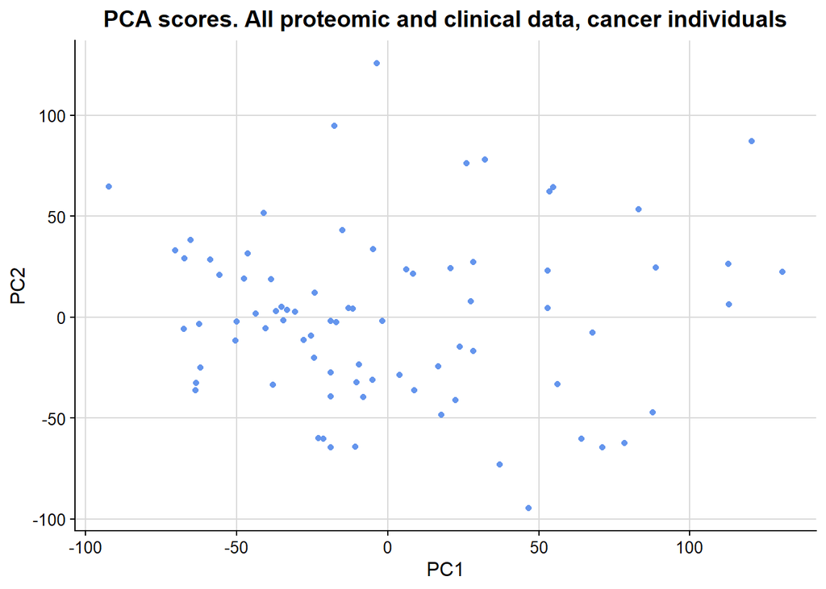

```r
pca_scores <- as.data.frame(predict(pca_prot_fit))

ggplot(pca_scores, aes(PC1, PC2)) +
  geom_point(size = 1.5, color = "cornflowerblue") +
  labs(title = "PCA scores. All proteomic and clinical data, cancer individuals",
       x = "PC1",
       y = "PC2") +
  theme_half_open(12) +
  background_grid() +
  theme(plot.title = element_text(hjust = 0.5))
```

```r
pca_prot_fit |>
  tidy(matrix = "eigenvalues")
```

```
# A tibble: 80 × 4
      PC std.dev percent cumulative
   <dbl>   <dbl>   <dbl>      <dbl>
 1     1    50.7  0.127       0.127
 2     2    42.1  0.0876      0.214
 3     3    40.6  0.0813      0.296
 4     4    29.3  0.0423      0.338
 5     5    27.6  0.0377      0.376
 6     6    26.8  0.0354      0.411
 7     7    23.3  0.0269      0.438
 8     8    21.9  0.0236      0.462
 9     9    20.4  0.0206      0.482
10    10    20.1  0.0200      0.502
# ℹ 70 more rows
```

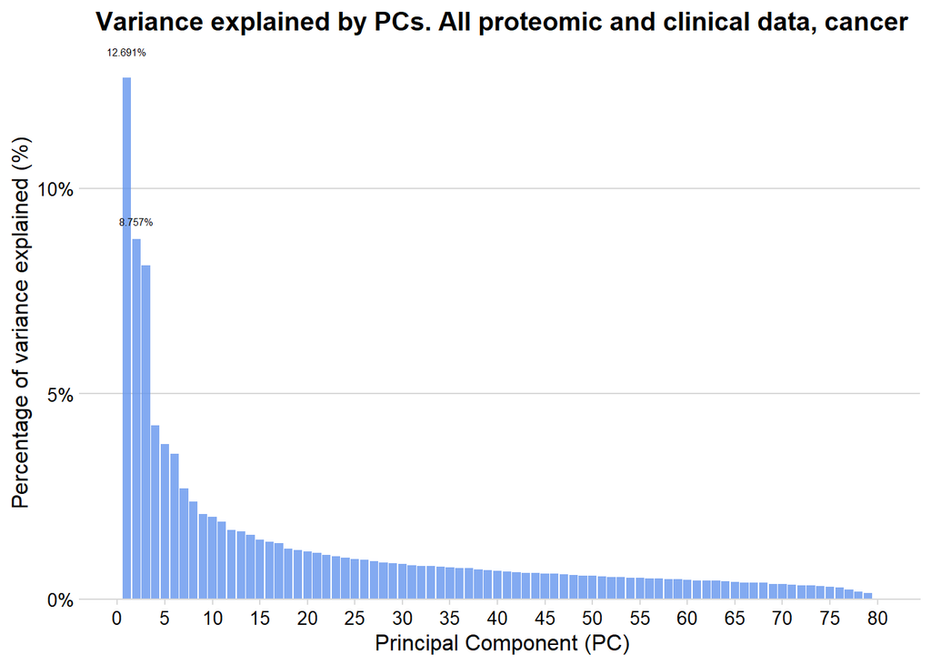

```r
pca_prot_fit |>
  tidy(matrix = "eigenvalues") |>
  ggplot(aes(PC,
             percent)) +
  geom_col(fill = "cornflowerblue",
           alpha = 0.8) +
  scale_x_continuous(breaks = seq(0,
                                  80,
                                  by = 5)) +
  scale_y_continuous(labels = scales::percent_format(),
                     expand = expansion(mult = c(0,
                                                 0.01))) +
  geom_text(mapping = aes(label = ifelse(PC %in% c(1, 2),
                                         scales::percent(percent),
                                         "")),
            position = position_stack(vjust = 1.05),
            color = "black",
            size = 2) +
  theme_minimal_hgrid(12) +
  labs(title = "Variance explained by PCs. All proteomic and clinical data, cancer",
       x = "Principal Component (PC)",
       y = "Percentage of variance explained (%)") +
  theme(plot.title = element_text(hjust = 0.5))
```

As done previously, in order to look for possible clusterings regarding certain variables, we plot the data on PC1 and PC2, and color regarding different variables. Since now we have included the clinical data, we explore more variables than before: tumor type, AJCC stage, age group, cancer subtype.

First, we make sure to drop the healthy individuals in all data structures used.

```r
prot_clin_exp <- prot_clin_exp |>
  filter(row_number() <= (n() - 3))
```

Now, we can inspect different variables.

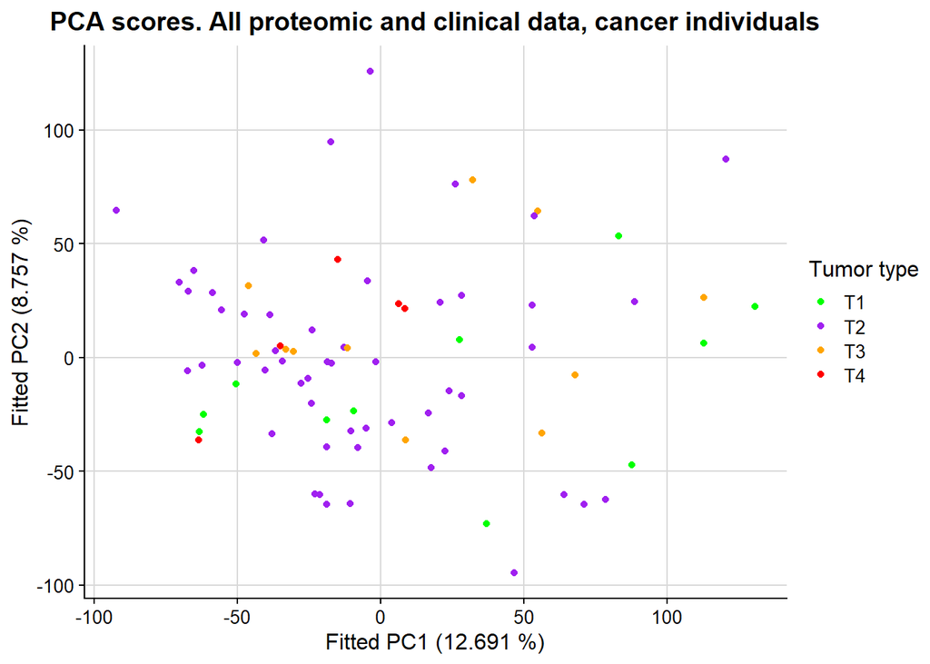

```r
pca_prot_fit |>
  augment(prot_clin_exp) |>
  ggplot(aes(.fittedPC1, .fittedPC2, color = Cancer_tumor)) +
  geom_point(size = 1.5) +
  scale_color_manual(
    values = c(T1 = "green",
               T2 = "purple",
               T3 = "orange",
               T4 = "red",
               Healthy = "blue")) +
  labs(title = "PCA scores. All proteomic and clinical data, cancer individuals",
       x = "Fitted PC1 (12.691 %)",
       y = "Fitted PC2 (8.757 %)",
       color = "Tumor type") +
  theme_half_open(12) +
  background_grid() +
  theme(plot.title = element_text(hjust = 0.5))
```

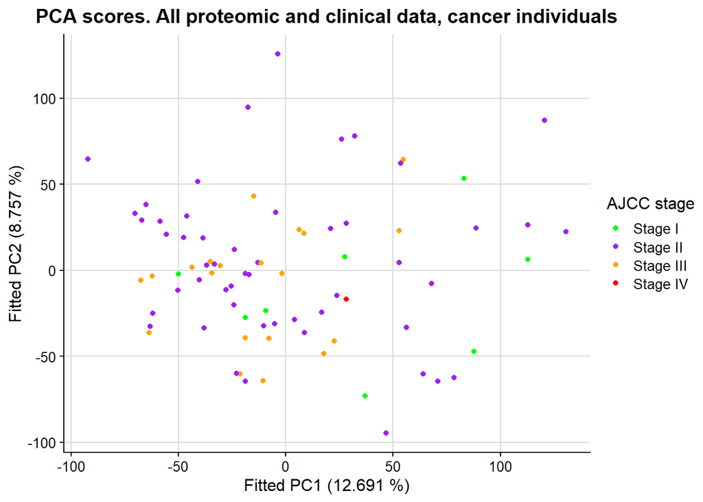

```r
pca_prot_fit |>
  augment(prot_clin_cancer) |>
  ggplot(aes(.fittedPC1, .fittedPC2, color = AJCC.Simp)) +
  geom_point(size = 1.5) +
  scale_color_manual(
    values = c("Stage I" = "green",
               "Stage II" = "purple",
               "Stage III" = "orange",
               "Stage IV" = "red",
               Healthy = "blue")) +
  labs(title = "PCA scores. All proteomic and clinical data, cancer individuals",
       x = "Fitted PC1 (12.691 %)",
       y = "Fitted PC2 (8.757 %)",
       color = "AJCC stage") +
  theme_half_open(12) +
  background_grid() +
  theme(plot.title = element_text(hjust = 0.5))
```

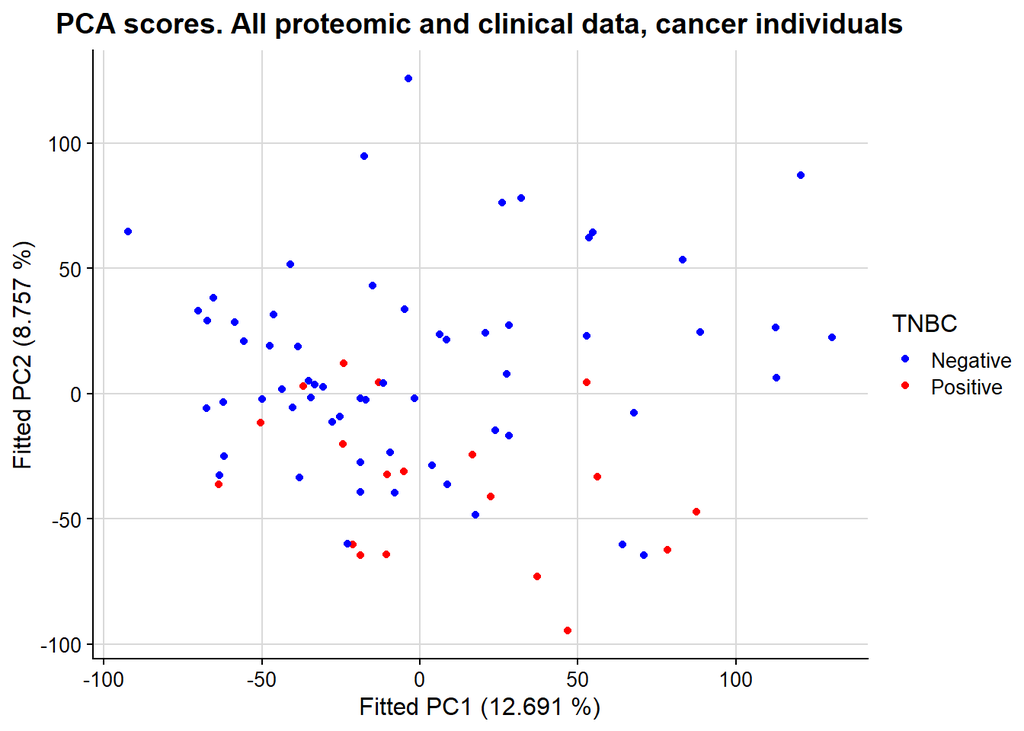

```r
pca_prot_fit |>
  augment(prot_clin_exp) |>
  ggplot(aes(.fittedPC1, .fittedPC2, color = TNBC_status)) +
  geom_point(size = 1.5) +
  scale_color_manual(
    values = c("Positive" = "red",
               "Negative" = "blue")) +
  labs(title = "PCA scores. All proteomic and clinical data, cancer individuals",
       x = "Fitted PC1 (12.691 %)",
       y = "Fitted PC2 (8.757 %)",
       color = "TNBC") +
  theme_half_open(12) +
  background_grid() +
  theme(plot.title = element_text(hjust = 0.5))
```

[figure not shown]

```r
pca_prot_fit |>
  augment(prot_clin_cancer) |>
  ggplot(aes(.fittedPC1, .fittedPC2, color = Age.Menopausal.group)) +
  geom_point(size = 1.5) +
  scale_color_manual(
    values = c("[30, 45)" = "blue",
               "[45, 55)" = "green",
               "[55, 90)" = "red")
  ) +
  labs(title = "PCA scores. All proteomic and clinical data, cancer individuals",
       x = "Fitted PC1 (12.691 %)",
       y = "Fitted PC2 (8.557 %)",
       color = "Age group") +
  theme_half_open(12) +
  background_grid() +
  theme(plot.title = element_text(hjust = 0.5))
```

[figure not shown]

```r
pca_prot_fit |>
  augment(prot_clin_cancer) |>
  ggplot(aes(.fittedPC1, .fittedPC2, color = PAM50.mRNA)) +
  geom_point(size = 1.5) +
  scale_color_manual(
    values = c("Basal-like" = "red",
               "Luminal A" = "green",
               "Luminal B" ="orange",
               "HER2-enriched" = "purple")) +
  labs(title = "PCA scores. All proteomic and clinical data, cancer individuals",
       x = "Fitted PC1 (12.691 %)",
       y = "Fitted PC2 (8.557 %)",
       color = "Cancer subtype") +
  theme_half_open(12) +
  background_grid() +
  theme(plot.title = element_text(hjust = 0.5))
```

After this analysis, it can be concluded that the addition of the clinical data does not significantly change the results when considering all proteomic data: the variance explained continues being too low for us to be able to exctract any meaningful conclusion just by looking at the two first principal components.

## 05.4. PCA for cancer samples including clinical data and PAM50 proteomic data.

In this last analysis, we replicated the steps of the previous section. However, in this case, the proteins not included in the PAM50 dataset were excluded for the analysis.

```r
PFAM_prot_cli <- prot_clin_cancer_encoded |>
  relocate(Age.Menopausal.group, .after = Gender) |>
  select(1:14, one_of(PAM50_ref_names))
```

```r
pca_PAM50_fit <- PFAM_prot_cli |>
  prcomp(scale=FALSE)
```

We plot the data on the two first principal components.

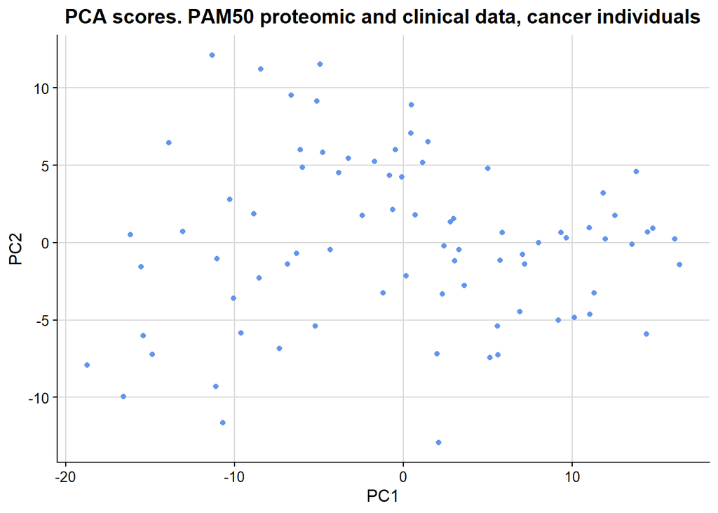

```r
pca_scores <- as.data.frame(predict(pca_PAM50_fit))

ggplot(pca_scores, aes(PC1, PC2)) +
  geom_point(size = 1.5, color = "cornflowerblue") +
  labs(title = "PCA scores. PAM50 proteomic and clinical data, cancer individuals",
       x = "PC1",
       y = "PC2") +
  theme_half_open(12) +
  background_grid() +
  theme(plot.title = element_text(hjust = 0.5))
```

```r
pca_PAM50_fit |>
  tidy(matrix = "eigenvalues")
```

```
# A tibble: 47 × 4
      PC std.dev percent cumulative
   <dbl>   <dbl>   <dbl>      <dbl>
 1     1    9.12  0.397       0.397
 2     2    5.39  0.139       0.535
 3     3    4.05  0.0783      0.614
 4     4    3.76  0.0675      0.681
 5     5    3.43  0.0561      0.737
 6     6    2.89  0.0399      0.777
 7     7    2.47  0.0292      0.807
 8     8    2.37  0.0268      0.833
 9     9    2.13  0.0216      0.855
10    10    1.96  0.0184      0.873
# ℹ 37 more rows
```

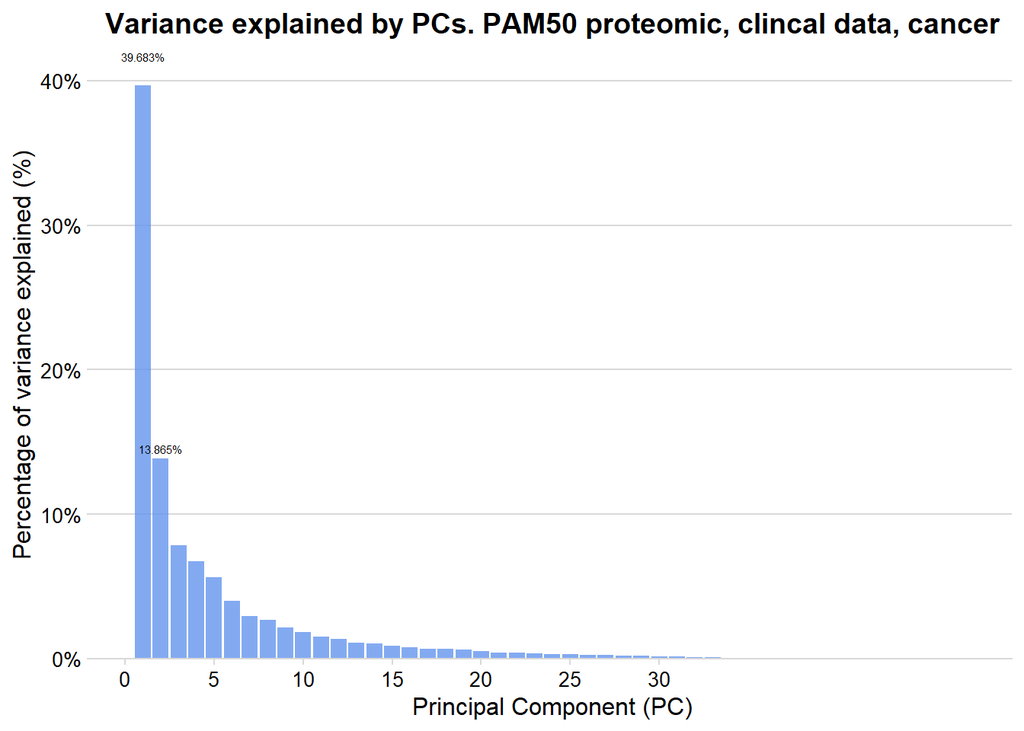

```r
pca_PAM50_fit |>
  tidy(matrix = "eigenvalues") |>
  ggplot(aes(PC,
             percent)) +
  geom_col(fill = "cornflowerblue",
           alpha = 0.8) +
  scale_x_continuous(breaks = seq(0,
                                  30,
                                  by = 5)) +
  scale_y_continuous(labels = scales::percent_format(),
                     expand = expansion(mult = c(0,
                                                 0.01))) +
  geom_text(mapping = aes(label = ifelse(PC %in% c(1, 2),
                                         scales::percent(percent),
                                         "")),
            position = position_stack(vjust = 1.05),
            color = "black",
            size = 2) +
  theme_minimal_hgrid(12) +
  labs(title = "Variance explained by PCs. PAM50 proteomic, clincal data, cancer",
       x = "Principal Component (PC)",
       y = "Percentage of variance explained (%)") +
  theme(plot.title = element_text(hjust = 0.5))
```

Now, we can do the usual exploratory analysis considering the same variables as in the previous section.

[figure not shown]

```r
pca_PAM50_fit |>
  augment(prot_clin_exp) |>
  ggplot(aes(.fittedPC1, .fittedPC2, color = Cancer_tumor)) +
  geom_point(size = 1.5) +
  scale_color_manual(
    values = c(T1 = "green",
               T2 = "purple",
               T3 = "blue",
               T4 = "red"
               )) +
  labs(title = "PCA scores. PAM50 proteomic and clinical data, cancer individuals",
       x = "Fitted PC1 (39.538 %)",
       y = "Fitted PC2 (14.549 %)",
       color = "Tumor") +
  theme_half_open(12) +
  background_grid() +
  theme(plot.title = element_text(hjust = 0.5))
```

[figure not shown]

```r
pca_PAM50_fit |>
  augment(prot_clin_cancer) |>
  ggplot(aes(.fittedPC1, .fittedPC2, color = AJCC.Simp)) +
  geom_point(size = 1.5) +
  scale_color_manual(
    values = c("Stage I" = "green",
               "Stage II" = "purple",
               "Stage III" = "orange",
               "Stage IV" = "red",
               Healthy = "blue")
  ) +
  labs(title = "PCA scores. PAM50 proteomic and clinical data, cancer individuals",
       x = "Fitted PC1 (39.538 %)",
       y = "Fitted PC2 (14.549 %)",
       color = "AJCC Stage") +
  theme_half_open(12) +
  background_grid() +
  theme(plot.title = element_text(hjust = 0.5))
```

[figure not shown]

```r
pca_PAM50_fit |>
  augment(prot_clin_exp) |>
  ggplot(aes(.fittedPC1, .fittedPC2, color = TNBC_status)) +
  geom_point(size = 1.5) +
  scale_color_manual(
    values = c("Positive" = "red1",
               "Negative" = "blue")
  ) +
  labs(title = "PCA scores. PAM50 proteomic and clinical data, cancer individuals",
       x = "Fitted PC1 (39.538 %)",
       y = "Fitted PC2 (14.549 %)",
       color = "TNBC") +
  theme_half_open(12) +
  background_grid() +
  theme(plot.title = element_text(hjust = 0.5),
        plot.background = element_rect(fill = "white"))
```

[figure not shown]

```r
pca_PAM50_fit |>
  augment(prot_clin_cancer) |>
  ggplot(aes(.fittedPC1, .fittedPC2, color = Age.Menopausal.group)) +
  geom_point(size = 1.5) +
  scale_color_manual(
    values = c("[30, 45)" = "blue",
               "[45, 55)" = "green",
               "[55, 90)" = "red")
  ) +
  labs(title = "PCA scores. PAM50 proteomic and clinical data, cancer individuals",
       x = "Fitted PC1 (39.538 %)",
       y = "Fitted PC2 (14.549 %)",
       color = "Age group") +
  theme_half_open(12) +
  background_grid() +
  theme(plot.title = element_text(hjust = 0.5))
```

[figure not shown]

```r
pca_PAM50_fit |>
  augment(prot_clin_cancer) |>
  ggplot(aes(.fittedPC1, .fittedPC2, color = PAM50.mRNA)) +
  geom_point(size = 1.5) +
  scale_color_manual(
    values = c("Basal-like" = "red",
               "Luminal A" = "green",
               "Luminal B" ="orange",
               "HER2-enriched" = "purple")
  ) +
  labs(title = "PCA scores. PAM50 proteomic and clinical data, cancer individuals",
       x = "Fitted PC1 (39.538 %)",
       y = "Fitted PC2 (14.549 %)",
       color = "Tumor") +
  theme_half_open(12) +
  background_grid() +
  theme(plot.title = element_text(hjust = 0.5),
        plot.background = element_rect(fill = "white"))
```

In this last section, we get a very clear separation between individuals suffering from TNBC and the rest, and we also see possible clustering regarding cancer subtypes.